# Visualización de Datos: Práctica 2

Autor: Pablo Román-Naranjo Varela

Junio 2022

# 1 Set de datos

El set de datos elegido se enmarca dentro del Women in Data Science (WiDS) Datathon 2020, un reto lanzado en 2020 por Kaggle con motivo de la Global WiDS Conference. En este dataset se incluyen registros sobre pacientes ingresados en la UCI durante un año en hospitales de Argentina, Australia, Nueva Zelanda, Sri Lanka, Brasil y Estados Unidos.

Los registros que componen este set de datos fueron recogidos en el año 2020, por lo que los resultados que se obtengan se podrán trasladar fácilmente a la actualidad. El tema del que trata es de especial interés para médicos e investigadores clínicos. No obstante, al tratar sobre salud, es un tema que puede llegar a interesar a la población en general. Entre las variables incluidas en este set de datos se incluye el género (variable binaria), por lo que se podrá discernir fácilmente entre tendencias asociadas al género masculino o femenino.

He seleccionado esta temática basándome, principalmente, en mi formación previa, graduado en Bioquímica y doctor en Biomedicina. El set de datos ha sido seleccionado debido a su complejidad y la fiabilidad de la fuente. Originalmente, en este juego de datos se incluyen un total de 91.713 registros, de los que se recogen valores para 186 características/variables. Estas variables, numéricas, binarias o categóricas, se clasifican en:

- **Variables identificativas** (3 variables): Identificadores asociados al paciente o al hospital
- **Variables demográficas** (16 variables): Edad, genero, peso, altura, etc.…
- **Variables APACHE** (40 variables): Variables asociadas al sistema de clasificación APACHE, un sistema para clasificar la severidad de una enfermedad.
- **Variables vitales** (52 variables): Presión sanguínea, frecuencia respiratoria, temperatura etc… durante las primeras 24 horas.
- **Variables de laboratorio** (76 variables): Niveles de calcio, bilirrubina, plaquetas, glucosa, etc… durante las primeras 24 horas.

Debido al número elevado de variables, no se detallaran cada una de ellas de manera específica. No obstante, esta información puede ser consultada desde el archivo adjunto (dictionary).

# 2 Análisis exploratorio.

El primer paso será la carga del archivo mediante la función **read.csv()**. Posteriormente comprobamos que el juego de datos ha sido cargado correctamente visualizando sus primeros registros con la función **head()**. Hacemos uso de la librería **DT** y su función **datatable()** para una mejor visualización en HTML.

Los métodos de visualización usados para el análisis de este set de datos se pueden consultar en [Tableau](https://public.tableau.com/app/profile/pablo.roman/viz/FactoresderiesgoenlamortalidaddepacientesenUCI/Historia?publish=yes).

```r
path = 'set_original.csv'
patientData = read.csv(path, row.names=NULL, sep = ",", na.strings=c("","NA"))
datatable(head(patientData), extensions = "FixedColumns", options = list(dom= 't', scrollX= TRUE, fixedColumns = TRUE))
```

|  | encounter_id | patient_id | hospital_id | hospital_death | age | bmi | elective_surgery | ethnicity | gender | height | hospital_admit_source | icu_admit_source | icu_id | icu_stay_type | icu_type | pre_icu_los_days | readmission_status | weight | albumin_apache | apache_2_diagnosis | apache_3j_diagnosis | apache_post_operative | arf_apache | bilirubin_apache | bun_apache | creatinine_apache | fio2_apache | gcs_eyes_apache | gcs_motor_apache | … |
| --- | --- | --- | --- | --- | --- | --- | --- | --- | --- | --- | --- | --- | --- | --- | --- | --- | --- | --- | --- | --- | --- | --- | --- | --- | --- | --- | --- | --- | --- | --- |
| 1 | 66154 | 25312 | 118 | 0 | 68 | 22.73 | 0 | Caucasian | M | 180.3 | Floor | Floor | 92 | admit | CTICU | 0.541666667 | 0 | 73.9 | 2.3 | 113 | 502.01 | 0 | 0 | 0.4 | 31 | 2.51 |  | 3 | 6 | … |
| 2 | 114252 | 59342 | 81 | 0 | 77 | 27.42 | 0 | Caucasian | F | 160 | Floor | Floor | 90 | admit | Med-Surg ICU | 0.927777778 | 0 | 70.2 |  | 108 | 203.01 | 0 | 0 |  | 9 | 0.56 | 1 | 1 | 3 | … |
| 3 | 119783 | 50777 | 118 | 0 | 25 | 31.95 | 0 | Caucasian | F | 172.7 | Emergency Department | Accident &amp; Emergency | 93 | admit | Med-Surg ICU | 0.000694444 | 0 | 95.3 |  | 122 | 703.03 | 0 | 0 |  |  |  |  | 3 | 6 | … |
| 4 | 79267 | 46918 | 118 | 0 | 81 | 22.64 | 1 | Caucasian | F | 165.1 | Operating Room | Operating Room / Recovery | 92 | admit | CTICU | 0.000694444 | 0 | 61.7 |  | 203 | 1206.03 | 1 | 0 |  |  |  | 0.6 | 4 | 6 | … |
| 5 | 92056 | 34377 | 33 | 0 | 19 |  | 0 | Caucasian | M | 188 |  | Accident &amp; Emergency | 91 | admit | Med-Surg ICU | 0.073611111 | 0 |  |  | 119 | 601.01 | 0 | 0 |  |  |  |  |  |  | … |
| 6 | 33181 | 74489 | 83 | 0 | 67 | 27.56 | 0 | Caucasian | M | 190.5 | Direct Admit | Accident &amp; Emergency | 95 | admit | Med-Surg ICU | 0.000694444 | 0 | 100 |  | 301 | 403.01 | 0 | 0 |  | 13 | 0.71 |  | 4 | 6 | … |

Se examina por primera vez la estructura general del set de datos con la función **str()**.

```r
structure = str(patientData)
```

```
## 'data.frame':    91713 obs. of  186 variables:
##  $ encounter_id                 : int  66154 114252 119783 79267 92056 33181 82208 120995 80471 42871 ...
##  $ patient_id                   : int  25312 59342 50777 46918 34377 74489 49526 50129 10577 90749 ...
##  $ hospital_id                  : int  118 81 118 118 33 83 83 33 118 118 ...
##  $ hospital_death               : int  0 0 0 0 0 0 0 0 1 0 ...
##  $ age                          : int  68 77 25 81 19 67 59 70 45 50 ...
##  $ bmi                          : num  22.7 27.4 31.9 22.6 NA ...
##  $ elective_surgery             : int  0 0 0 1 0 0 0 0 0 0 ...
##  $ ethnicity                    : chr  "Caucasian" "Caucasian" "Caucasian" "Caucasian" ...
##  $ gender                       : chr  "M" "F" "F" "F" ...
##  $ height                       : num  180 160 173 165 188 ...
##  $ hospital_admit_source        : chr  "Floor" "Floor" "Emergency Department" "Operating Room" ...
##  $ icu_admit_source             : chr  "Floor" "Floor" "Accident & Emergency" "Operating Room / Recovery" ...
##  $ icu_id                       : int  92 90 93 92 91 95 95 91 114 114 ...
##  $ icu_stay_type                : chr  "admit" "admit" "admit" "admit" ...
```

[output cut: 86 more lines]

Como podemos comprobar, tenemos **186 variables** y **91.713 registros**. También vemos el tipo de cada variable y algunos de los valores que pueden tomar.

Antes de seguir trabajando con estos datos, debemos tener claro el significado de cada una de estas variables. Esto se puede consultar en el archivo adjunto llamado dictionary.csv. En el siguiente apartado analizaremos estas variables de una manera más detenida.

# 3 Tareas de limpieza, acondicionado, discretización y selección de características

El primer paso que tomaremos para preparar el juego de datos será la limpieza de datos o *data cleaning* y la selección de características. Veamos el número de valores nulos en cada una de nuestras variables.

```r
# Valores nulos
colSums(is.na(patientData))
```

```
##                  encounter_id                    patient_id
##                             0                             0
##                   hospital_id                hospital_death
##                             0                             0
##                           age                           bmi
##                          4228                          3429
##              elective_surgery                     ethnicity
##                             0                          1395
##                        gender                        height
##                            25                          1334
##         hospital_admit_source              icu_admit_source
##                         21409                           112
##                        icu_id                 icu_stay_type
##                             0                             0
##                      icu_type              pre_icu_los_days
##                             0                             0
##            readmission_status                        weight
##                             0                          2720
##                albumin_apache            apache_2_diagnosis
##                         54379                          1662
##           apache_3j_diagnosis         apache_post_operative
##                          1101                             0
##                    arf_apache              bilirubin_apache
##                           715                         58134
##                    bun_apache             creatinine_apache
##                         19262                         18853
##                   fio2_apache               gcs_eyes_apache
##                         70868                          1901
##              gcs_motor_apache             gcs_unable_apache
##                          1901                          1037
##             gcs_verbal_apache                glucose_apache
##                          1901                         11036
##             heart_rate_apache             hematocrit_apache
##                           878                         19878
##              intubated_apache                    map_apache
##                           715                           994
##                  paco2_apache           paco2_for_ph_apache
##                         70868                         70868
##                   pao2_apache                     ph_apache
##                         70868                         70868
```

[output cut: 131 more lines]

```
##                         75945                         75945
##          h1_pao2fio2ratio_max          h1_pao2fio2ratio_min
##                         80195                         80195
## apache_4a_hospital_death_prob      apache_4a_icu_death_prob
##                          7947                          7947
##                          aids                     cirrhosis
##                           715                           715
##             diabetes_mellitus               hepatic_failure
##                           715                           715
##             immunosuppression                      leukemia
##                           715                           715
##                      lymphoma   solid_tumor_with_metastasis
##                           715                           715
##          apache_3j_bodysystem           apache_2_bodysystem
##                          1662                          1662
```

Para ser sinceros, tantas variables abruman. Veamos primero las **variables categóricas**, analizando qué valores toman.

## 3.1 Variables categóricas

Seleccionamos las variables categóricas mediante la función sapply() y observamos los valores que toman.

```r
is_char = sapply(patientData, is.character)
patientData_char = patientData[, is_char]
head(patientData_char)
```

```
##   ethnicity gender hospital_admit_source          icu_admit_source
## 1 Caucasian      M                 Floor                     Floor
## 2 Caucasian      F                 Floor                     Floor
## 3 Caucasian      F  Emergency Department      Accident & Emergency
## 4 Caucasian      F        Operating Room Operating Room / Recovery
## 5 Caucasian      M                  <NA>      Accident & Emergency
## 6 Caucasian      M          Direct Admit      Accident & Emergency
##   icu_stay_type     icu_type apache_3j_bodysystem apache_2_bodysystem
## 1         admit        CTICU               Sepsis      Cardiovascular
## 2         admit Med-Surg ICU          Respiratory         Respiratory
## 3         admit Med-Surg ICU            Metabolic           Metabolic
## 4         admit        CTICU       Cardiovascular      Cardiovascular
## 5         admit Med-Surg ICU               Trauma              Trauma
## 6         admit Med-Surg ICU         Neurological          Neurologic
```

```r
for(i in 1:ncol(patientData_char)){
  print(sprintf("Valores para la columna %s:", colnames(patientData_char)[i]))
  print(sort(unique(patientData_char[, i]))
)}
```

```
## [1] "Valores para la columna ethnicity:"
## [1] "African American" "Asian"            "Caucasian"        "Hispanic"
## [5] "Native American"  "Other/Unknown"
## [1] "Valores para la columna gender:"
## [1] "F" "M"
## [1] "Valores para la columna hospital_admit_source:"
##  [1] "Acute Care/Floor"     "Chest Pain Center"    "Direct Admit"
##  [4] "Emergency Department" "Floor"                "ICU"
##  [7] "ICU to SDU"           "Observation"          "Operating Room"
## [10] "Other"                "Other Hospital"       "Other ICU"
## [13] "PACU"                 "Recovery Room"        "Step-Down Unit (SDU)"
## [1] "Valores para la columna icu_admit_source:"
## [1] "Accident & Emergency"      "Floor"
## [3] "Operating Room / Recovery" "Other Hospital"
## [5] "Other ICU"
## [1] "Valores para la columna icu_stay_type:"
## [1] "admit"    "readmit"  "transfer"
## [1] "Valores para la columna icu_type:"
## [1] "Cardiac ICU"  "CCU-CTICU"    "CSICU"        "CTICU"        "Med-Surg ICU"
## [6] "MICU"         "Neuro ICU"    "SICU"
## [1] "Valores para la columna apache_3j_bodysystem:"
##  [1] "Cardiovascular"       "Gastrointestinal"     "Genitourinary"
##  [4] "Gynecological"        "Hematological"        "Metabolic"
##  [7] "Musculoskeletal/Skin" "Neurological"         "Respiratory"
## [10] "Sepsis"               "Trauma"
## [1] "Valores para la columna apache_2_bodysystem:"
##  [1] "Cardiovascular"      "Gastrointestinal"    "Haematologic"
##  [4] "Metabolic"           "Neurologic"          "Renal/Genitourinary"
##  [7] "Respiratory"         "Trauma"              "Undefined diagnoses"
## [10] "Undefined Diagnoses"
```

Podemos observar que en algunas de estas varibles existen categorías para un mismo valor. Como ejemplo, en la variable ‘apache_2_bodysystem’ existen las categorías ‘Undefined diagnoses’ y ‘Undefined Diagnoses’. Esto debe ser corregido. De igual manera se corregiran (agruparán) en las otras variables las siguientes categorías:

- En la columna ‘hospital_admit_source’ se agruparán los valores:
  - ‘Other ICU’ e ‘ICU’ en ‘ICU’
  - ‘ICU to SDU’ y ‘Step-Down Unit (SDU)’ en ‘Step-Down Unit (SDU)’
  - ‘Other Hospital’ y ‘Other’ en ‘Other’
  - ‘Recovery Room’ y ‘Observation’ en ‘Observation’
- En la columna ‘icu_type’ se agruparán los valores ‘CCU-CTICU’, ‘CTICU’, ‘Cardiac ICU’, ya que referencian lo mismo.

```r
# apache_2_bodysystem
patientData["apache_2_bodysystem"][patientData["apache_2_bodysystem"] == "Undefined Diagnoses"] = "Undefined diagnoses"
sort(unique(patientData[, "apache_2_bodysystem"]))
```

```
## [1] "Cardiovascular"      "Gastrointestinal"    "Haematologic"
## [4] "Metabolic"           "Neurologic"          "Renal/Genitourinary"
## [7] "Respiratory"         "Trauma"              "Undefined diagnoses"
```

```r
# hospital_admit_source
patientData["hospital_admit_source"][patientData["hospital_admit_source"] == "Other ICU"] = "ICU"
patientData["hospital_admit_source"][patientData["hospital_admit_source"] == "ICU to SDU"] = "Step-Down Unit (SDU)"
patientData["hospital_admit_source"][patientData["hospital_admit_source"] == "Other Hospital"] = "Other"
patientData["hospital_admit_source"][patientData["hospital_admit_source"] == "Recovery Room"] = "Observation"
sort(unique(patientData[, "hospital_admit_source"]))
```

```
##  [1] "Acute Care/Floor"     "Chest Pain Center"    "Direct Admit"
##  [4] "Emergency Department" "Floor"                "ICU"
##  [7] "Observation"          "Operating Room"       "Other"
## [10] "PACU"                 "Step-Down Unit (SDU)"
```

```r
# icu_type
patientData["icu_type"][patientData["icu_type"] == "CCU-CTICU" | patientData["icu_type"] == "Cardiac ICU" ] = "CTICU"
sort(unique(patientData[, "icu_type"]))
```

```
## [1] "CSICU"        "CTICU"        "Med-Surg ICU" "MICU"         "Neuro ICU"
## [6] "SICU"
```

Una vez procesadas estas variables, podemos utilizar métodos de visualización para analizar la distribución de valores. Estas y otras visualizaciones, realizadas en Tableau, se analizarán en el video que acompaña a esta práctica.

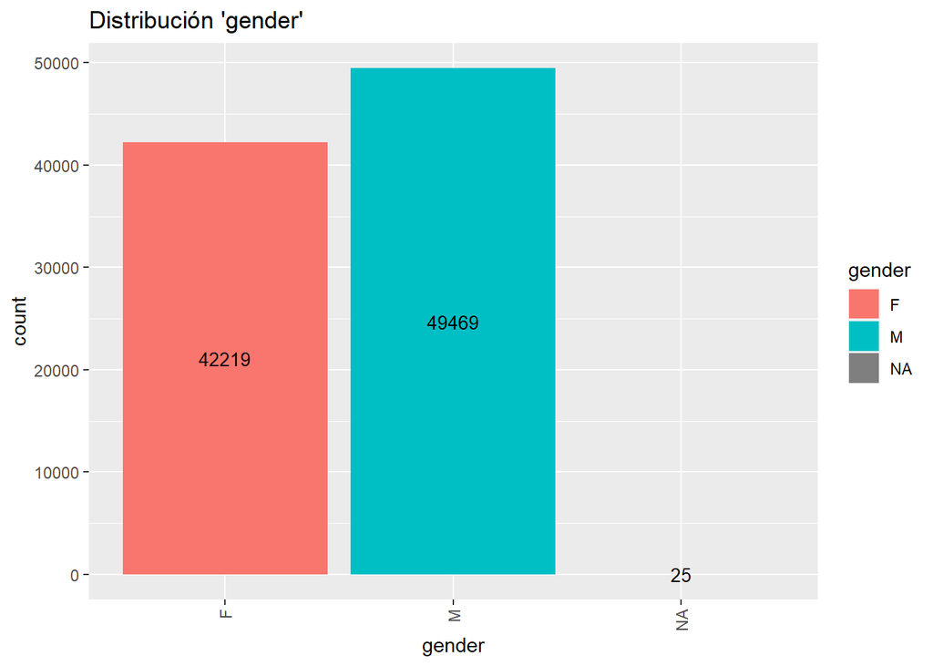

```r
d1 = ggplot(patientData, aes(x=gender, fill=gender)) + geom_bar() +
  theme(axis.text.x = element_text(angle = 90, vjust = 0.5, hjust=1)) +
  ggtitle("Distribución 'gender'") +
  stat_count(geom = "text", colour = "black", size = 3.5, aes(label = ..count..),
             position=position_stack(vjust=0.5))
d1
```

Comprobamos que la distribución en cuanto a genero está balanceada.

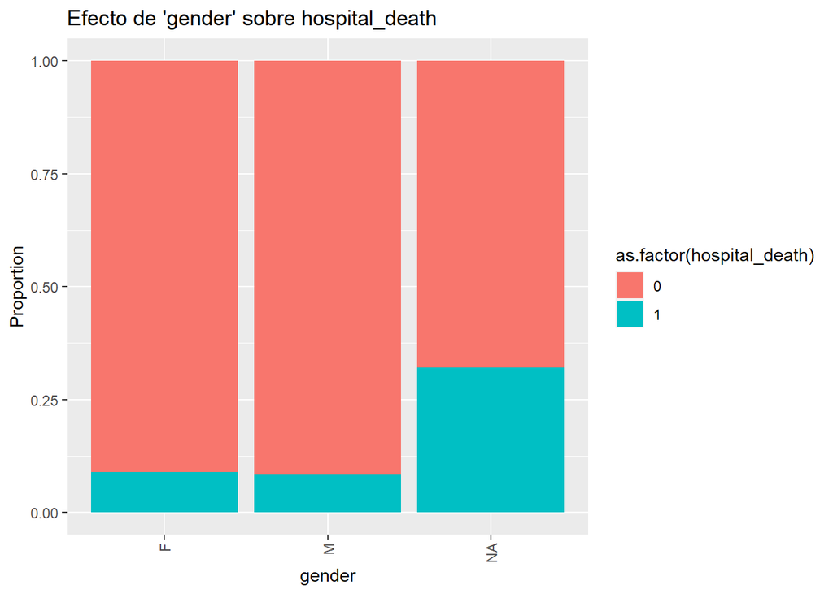

```r
ggplot(patientData,
       aes(x = gender,
           fill = as.factor(hospital_death))) +
  geom_bar(position = "fill") +
  labs(y = "Proportion") +
  theme(axis.text.x = element_text(angle = 90, vjust = 0.5, hjust=1)) +
  ggtitle("Efecto de 'gender' sobre hospital_death")
```

No obstante, parece que el hecho de ser mujer (F) o hombre (M) no afecta en la variable “hospital_death”.

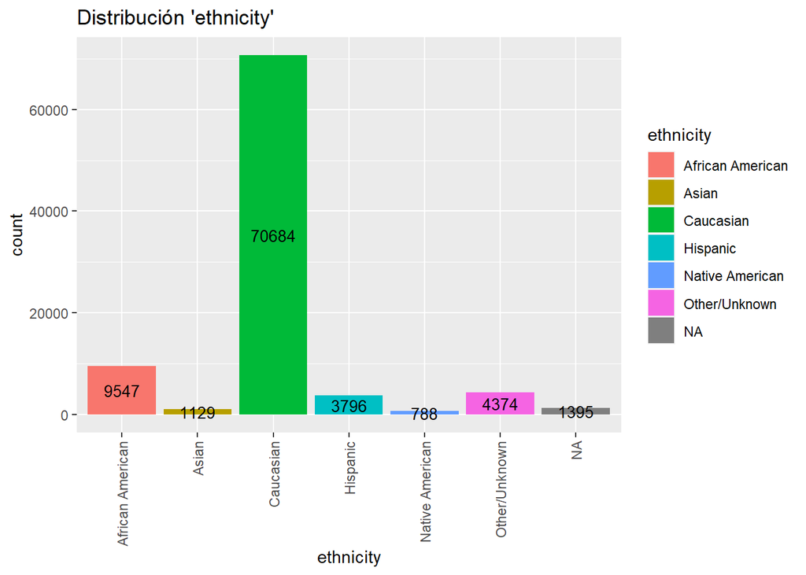

```r
d2 = ggplot(patientData, aes(x=ethnicity, fill=ethnicity)) + geom_bar() +
  theme(axis.text.x = element_text(angle = 90, vjust = 0.5, hjust=1)) +
  ggtitle("Distribución 'ethnicity'") +
  stat_count(geom = "text", colour = "black", size = 3.5, aes(label = ..count..),
             position=position_stack(vjust=0.5))
d2
```

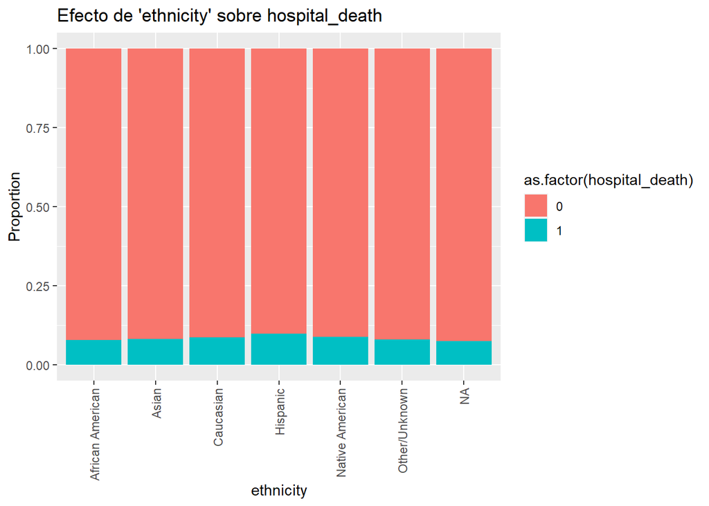

```r
ggplot(patientData,
       aes(x = ethnicity,
           fill = as.factor(hospital_death))) +
  geom_bar(position = "fill") +
  labs(y = "Proportion") +
  theme(axis.text.x = element_text(angle = 90, vjust = 0.5, hjust=1)) +
  ggtitle("Efecto de 'ethnicity' sobre hospital_death")
```

Lo mismo ocurre con la variable “ethnicity”, no parece afectar al hecho de que el paciente fallezca o no.

En este juego de datos nos encontramos con dos variables categóricas llamadas “apache_2_bodysystem” y “apache_3j_bodysystem”. Ambas hacen referencia al diagnóstico a la entrada del paciente en UCI, una de acuerdo a APACHE II y la otra de acuerdo a APACHE III, respectivamente.

APACHE (Acute Physiology and Chronic Health Evaluation) es un sistema de puntuación utilizado en UCI para valorar la severidad de una enfermedad y el riesgo de muerte en las primeras 24 horas de la entrada del paciente en UCI. Este parámetro puede tomar valores entre el 0 y el 71, entendiéndose un mayor riesgo cuanto mayor sea este valor.

APACHE III, desarrollado en 1990, es un sistema basado en APACHE II, desarrollado en 1985. Debido a esto, esperamos una alta correlación entre ambas variables. De acuerdo a un artículo publicado en 2001 en el que se valoraban ambos sistemas [1], se concluyó que APACHE III era un mejor estimador para el riesgo de mortalidad en UCI.

```r
head(patientData[, c("apache_2_bodysystem","apache_3j_bodysystem")], 15)
```

```
##    apache_2_bodysystem apache_3j_bodysystem
## 1       Cardiovascular               Sepsis
## 2          Respiratory          Respiratory
## 3            Metabolic            Metabolic
## 4       Cardiovascular       Cardiovascular
## 5               Trauma               Trauma
## 6           Neurologic         Neurological
## 7          Respiratory          Respiratory
## 8       Cardiovascular               Sepsis
## 9       Cardiovascular       Cardiovascular
## 10      Cardiovascular       Cardiovascular
## 11         Respiratory          Respiratory
## 12          Neurologic         Neurological
## 13          Neurologic         Neurological
## 14    Gastrointestinal     Gastrointestinal
## 15         Respiratory          Respiratory
```

Como vemos, solo hay cambios menores, como “Neurologic” (APACHE II) a “Neurological” (APACHE III) o reclasificiaciones, como de “Cardiovascular” a “Sepsis”. Esta reclasificación tiene sentido a nivel clínico, ya que una sepsis puede conllevar a una disfunción cardíaca. Eliminaremos la columna “apache_2_bodysystem” y analizaremos la variable “apache_3j_bodysystem”.

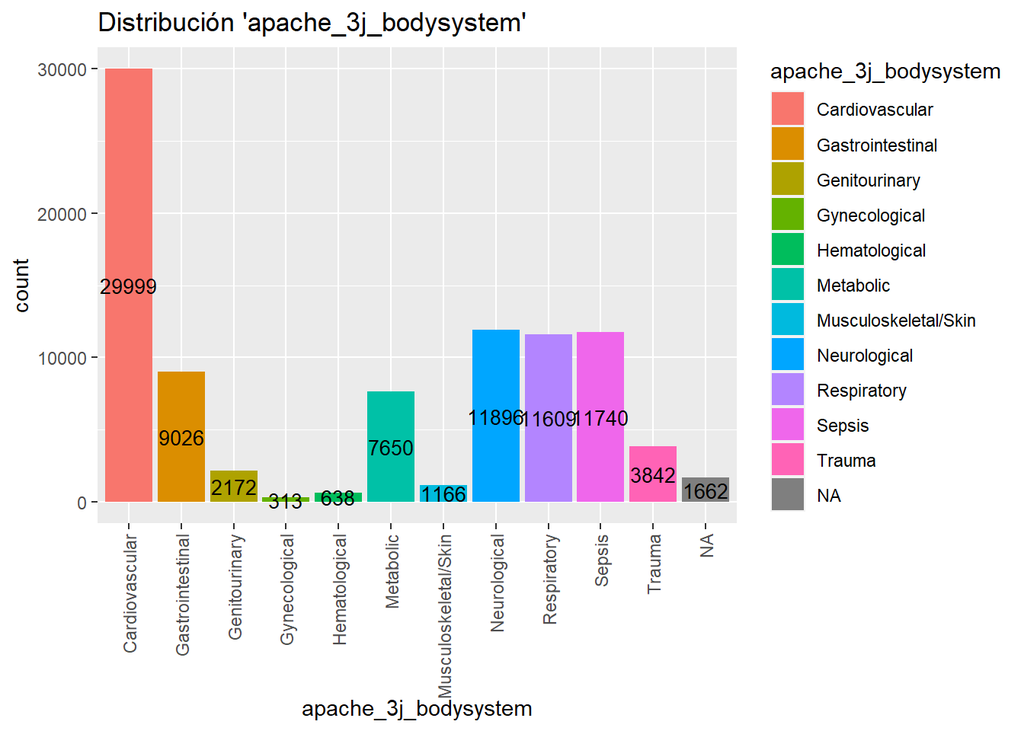

```r
patientData = patientData[, !(names(patientData) %in% "apache_2_bodysystem")]

d3 = ggplot(patientData, aes(x=apache_3j_bodysystem, fill = apache_3j_bodysystem)) + geom_bar() +
  theme(axis.text.x = element_text(angle = 90, vjust = 0.5, hjust=1)) +
  ggtitle("Distribución 'apache_3j_bodysystem'") +
  stat_count(geom = "text", colour = "black", size = 3.5, aes(label = ..count..),
             position=position_stack(vjust=0.5))
d3
```

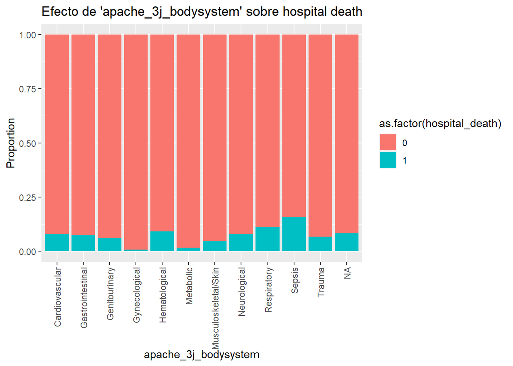

```r
ggplot(patientData,
       aes(x = apache_3j_bodysystem,
           fill = as.factor(hospital_death))) +
  geom_bar(position = "fill") +
  labs(y = "Proportion") +
  theme(axis.text.x = element_text(angle = 90, vjust = 0.5, hjust=1)) +
  ggtitle("Efecto de 'apache_3j_bodysystem' sobre hospital death")
```

En este caso vemos como claramente la variable “apache_3j_bodysystem” influye en “hospital_death”.

Exploremos el caso de la variable “icu_type”, que representa el tipo de cuidados que puede ofrecer la UCI.

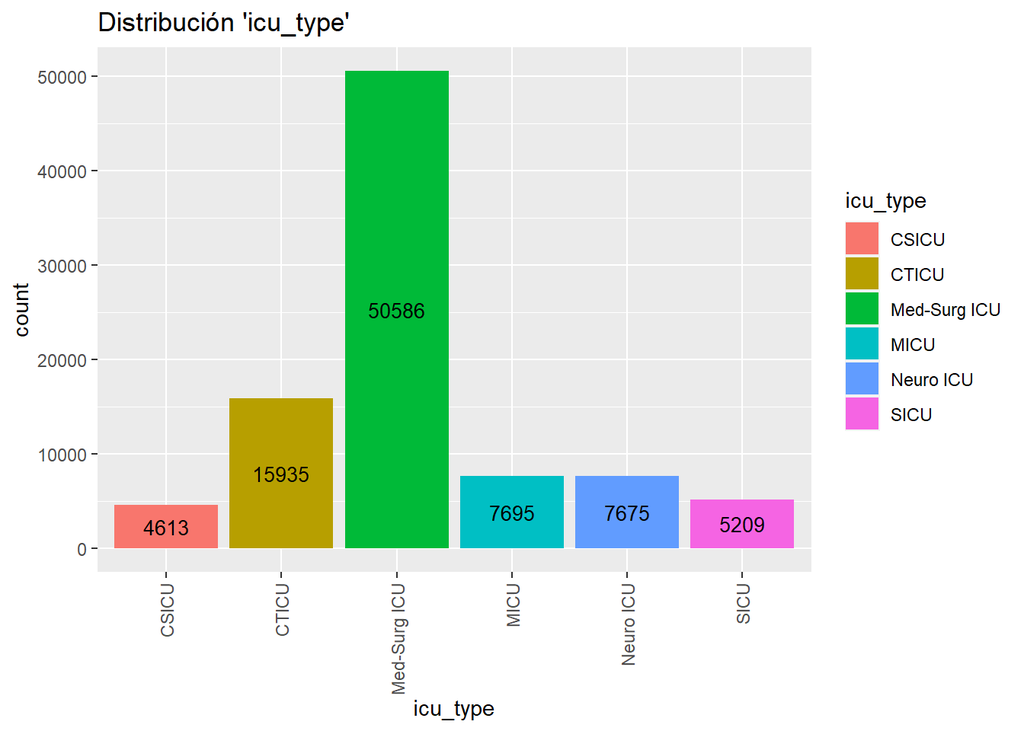

```r
d4 = ggplot(patientData, aes(x=icu_type, fill=icu_type)) + geom_bar() +
  theme(axis.text.x = element_text(angle = 90, vjust = 0.5, hjust=1)) +
  ggtitle("Distribución 'icu_type'") +
  stat_count(geom = "text", colour = "black", size = 3.5, aes(label = ..count..),
             position=position_stack(vjust=0.5))
d4
```

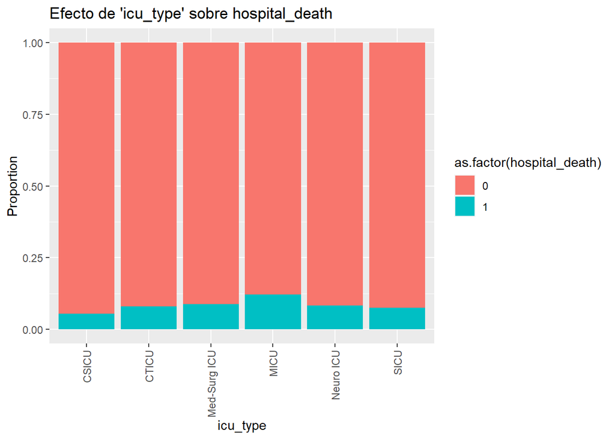

```r
ggplot(patientData,
       aes(x = icu_type,
           fill = as.factor(hospital_death))) +
  geom_bar(position = "fill") +
  labs(y = "Proportion") +
  theme(axis.text.x = element_text(angle = 90, vjust = 0.5, hjust=1)) +
  ggtitle("Efecto de 'icu_type' sobre hospital_death")
```

Vemos como hospital_death también se ve afectada por la variable icu_type. Exploremos finalmente las variables “hospital_admit_source”, “icu_admit_source” y “icu_stay_type”.

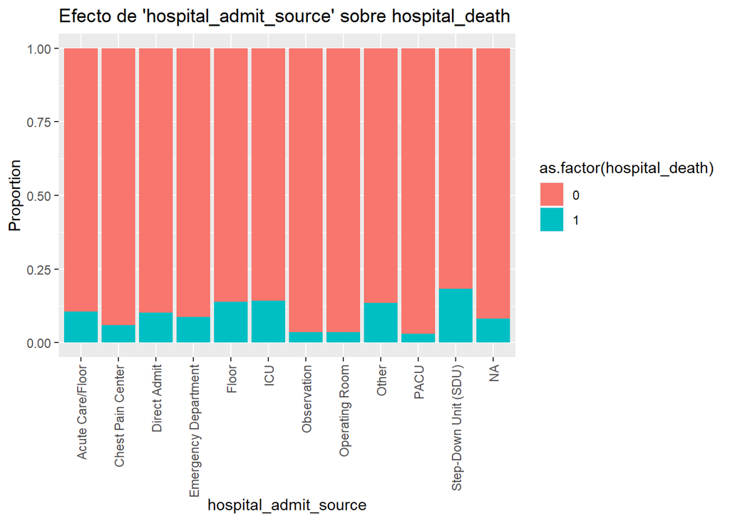

```r
ggplot(patientData,
       aes(x = hospital_admit_source,
           fill = as.factor(hospital_death))) +
  geom_bar(position = "fill") +
  labs(y = "Proportion") +
  theme(axis.text.x = element_text(angle = 90, vjust = 0.5, hjust=1)) +
  ggtitle("Efecto de 'hospital_admit_source' sobre hospital_death")
```

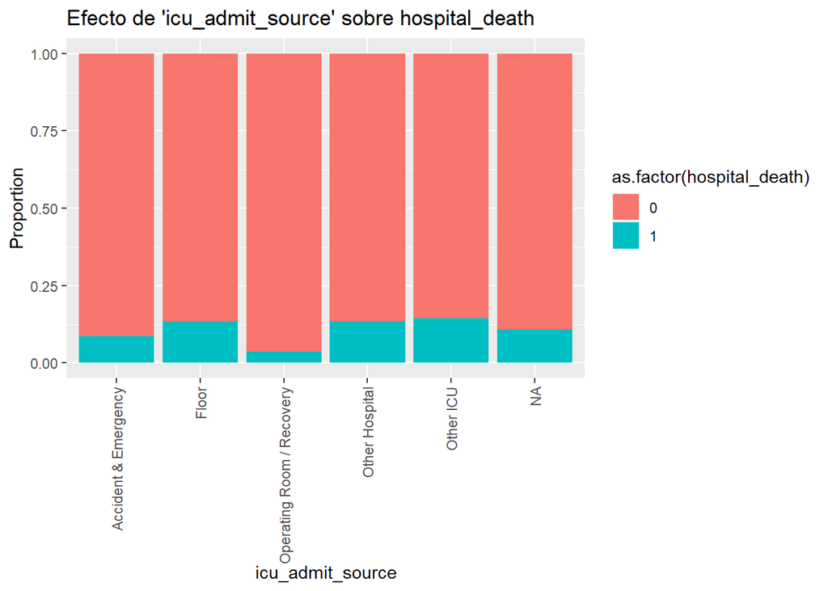

```r
ggplot(patientData,
       aes(x = icu_admit_source,
           fill = as.factor(hospital_death))) +
  geom_bar(position = "fill") +
  labs(y = "Proportion") +
  theme(axis.text.x = element_text(angle = 90, vjust = 0.5, hjust=1)) +
  ggtitle("Efecto de 'icu_admit_source' sobre hospital_death")
```

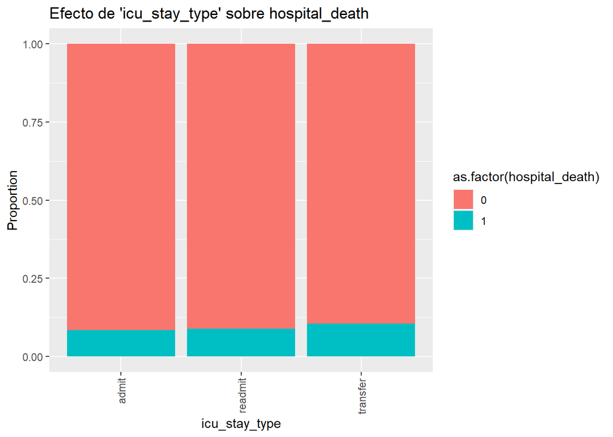

```r
ggplot(patientData,
       aes(x = icu_stay_type,
           fill = as.factor(hospital_death))) +
  geom_bar(position = "fill") +
  labs(y = "Proportion") +
  theme(axis.text.x = element_text(angle = 90, vjust = 0.5, hjust=1)) +
  ggtitle("Efecto de 'icu_stay_type' sobre hospital_death")
```

Comprobamos como “hospital_admit_source” y “icu_admit_source” afectan a hospital_death. Vemos el caso contrario en la variable “icu_stay_type”, que parece no afectar en el porcentaje de muertes.

```r
patientData = patientData[, !(names(patientData) %in% "icu_stay_type")]
```

## 3.2 Variables numéricas

### 3.2.1 Valores únicos y variables identificativas

Algunas de las características/variables de este juego de datos pueden ser eliminadas ya que no aportarán nada. Estas variables son aquellas que solo presentan un valor para todos los registros, o las variables identificativas del paciente (“patient_id” y “encounter_id”).

```r
# Variables con un solo valor
sapply(patientData, n_distinct)[sapply(patientData, n_distinct) == 1]
```

```
## readmission_status
##                  1
```

Pasamos a eliminar las columnas “patient_id”, “encounter_id” y “readmission_status”.

```r
patientData = patientData[, !(names(patientData) %in% c("patient_id", "encounter_id", "readmission_status"))]
```

### 3.2.2 Alta proporción de valores nulos

Por convención, otras variables que pueden ser descartadas son aquellas que incluyen más del 80% de valores nulos (NA). Observemos la proporción de valores nulos para cada una de las variables.

```r
naPerCent = sort(colSums(is.na(patientData)/length(patientData$bmi)*100), decreasing = TRUE)
names(naPerCent[naPerCent >= 80])
```

```
##  [1] "h1_bilirubin_max"       "h1_bilirubin_min"       "h1_lactate_max"
##  [4] "h1_lactate_min"         "h1_albumin_max"         "h1_albumin_min"
##  [7] "h1_pao2fio2ratio_max"   "h1_pao2fio2ratio_min"   "h1_arterial_ph_max"
## [10] "h1_arterial_ph_min"     "h1_hco3_max"            "h1_hco3_min"
## [13] "h1_arterial_pco2_max"   "h1_arterial_pco2_min"   "h1_wbc_max"
## [16] "h1_wbc_min"             "h1_arterial_po2_max"    "h1_arterial_po2_min"
## [19] "h1_calcium_max"         "h1_calcium_min"         "h1_platelets_max"
## [22] "h1_platelets_min"       "h1_bun_max"             "h1_bun_min"
## [25] "h1_creatinine_max"      "h1_creatinine_min"      "h1_diasbp_invasive_max"
## [28] "h1_diasbp_invasive_min" "h1_sysbp_invasive_max"  "h1_sysbp_invasive_min"
## [31] "h1_mbp_invasive_max"    "h1_mbp_invasive_min"    "h1_hematocrit_max"
## [34] "h1_hematocrit_min"
```

```r
# Variables a descartar
toDrop = names(naPerCent[naPerCent >= 80])
```

Como podemos comprobar, todas las variables con más de un 80 por ciento de valores nulos son variables “h1”. Estas variables hacen referencia al valor máximo tomado por un parámetro clínico en la primera hora del paciente en UCI. Por ejemplo, “h1_calcium_max” hace referencia a la concentración máxima de calcio en la primera hora de estancia del paciente en UCI. Descartamos estas variables.

```r
patientData = patientData[, !(names(patientData) %in% toDrop)]
```

### 3.2.3 Variables demográficas

Comprobemos ahora la distribución de las **Variables demográficas** numéricas (edad, peso, altura, IMC, etc…). Estudiemos primero la variable “Age”.

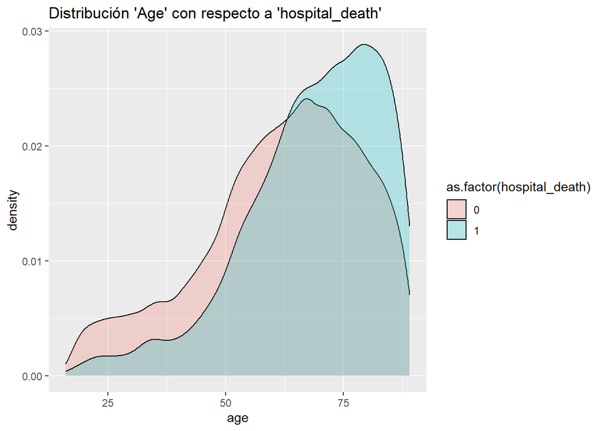

```r
ggplot(patientData,aes(x=age, fill=as.factor(hospital_death))) + geom_density(alpha=0.25) +
  ggtitle("Distribución 'Age' con respecto a 'hospital_death'")
```

Hablando de la variable edad (Age), podemos comprobar como la mayoría de registros son de pacientes mayores de 50. Además, comprobamos una distribución diferente en aquellos pacientes que han fallecido, existiendo una proporción mayor de pacientes con edad avanzada.

Pasemos a ver la distribución de las variables peso (weight) y altura (height).

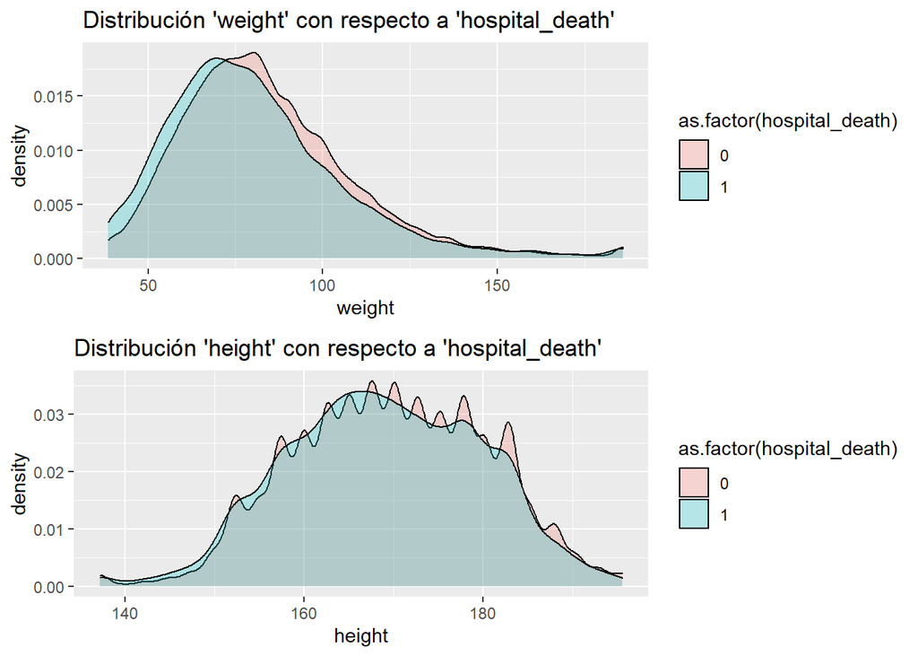

```r
# Peso
plot_peso = ggplot(patientData,aes(x=weight, fill=as.factor(hospital_death))) + geom_density(alpha=0.25) +
  ggtitle("Distribución 'weight' con respecto a 'hospital_death'")
# Altura
plot_altura = ggplot(patientData,aes(x=height, fill=as.factor(hospital_death))) + geom_density(alpha=0.25) +
  ggtitle("Distribución 'height' con respecto a 'hospital_death'")

grid.arrange(plot_peso, plot_altura, nrow = 2)
```

Vemos como ambas variables no parecen tomar valores anómalos. Además, parece que la distribución no varía demasiado cuando analizamos registros de fallecidos y no fallecidos.

#### 3.2.3.1 Discretizción de la variable “bmi

Veamos qué ocurre con la variable “bmi” (IMC), que depende de las dos primeras.

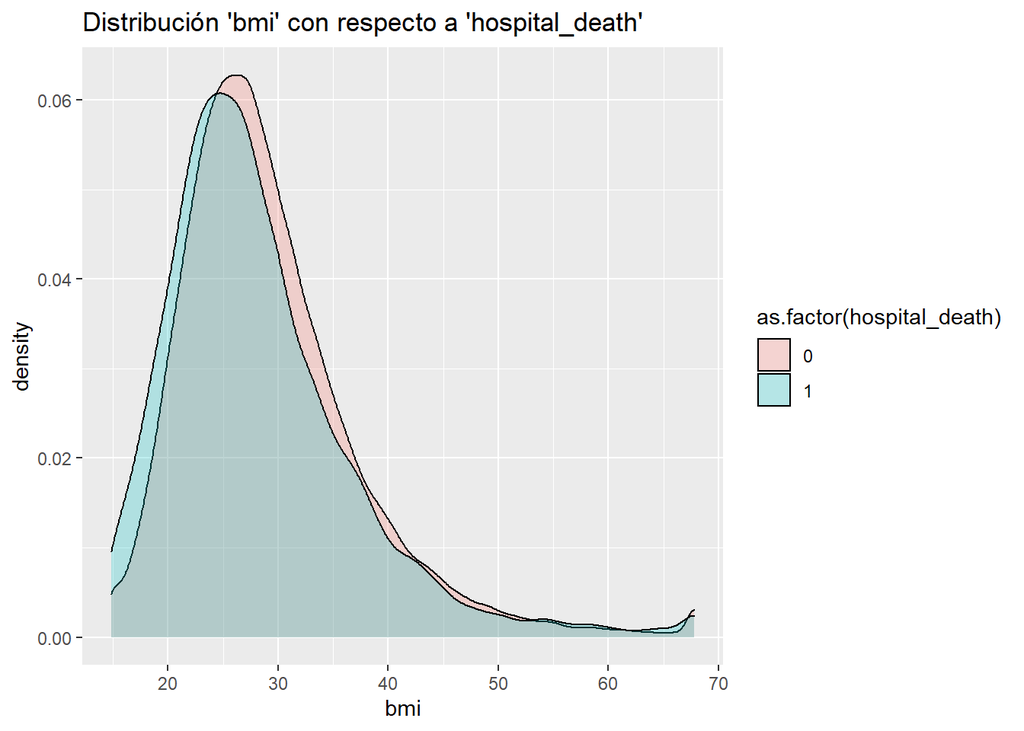

```r
# BMI
ggplot(patientData,aes(x=bmi, fill=as.factor(hospital_death))) + geom_density(alpha=0.25) +
  ggtitle("Distribución 'bmi' con respecto a 'hospital_death'")
```

No parece que la distribución varíe demasiado cuando analizamos registros de fallecidos y no fallecidos. No obstante, esta variable es ideal para su discretización sabiendo que dependiento del valor que tome podremos clasificar los pacientes en peso bajo, normal, sobrepeso u obeso. Pasemos a ello.

```r
patientData$bmi_cat = cut(patientData$bmi,
                       breaks=c(0, 18.5, 24.9, 29.9, max(patientData$bmi, na.rm = TRUE)),
                       labels=c('Bajo', 'Normal', 'Sobrepeso', 'Obeso'))
head(patientData[, c("bmi", "bmi_cat")])
```

```
##     bmi   bmi_cat
## 1 22.73    Normal
## 2 27.42 Sobrepeso
## 3 31.95     Obeso
## 4 22.64    Normal
## 5    NA      <NA>
## 6 27.56 Sobrepeso
```

Comprobemos si ha cambiado algo al discretizar la variable “bmi”.

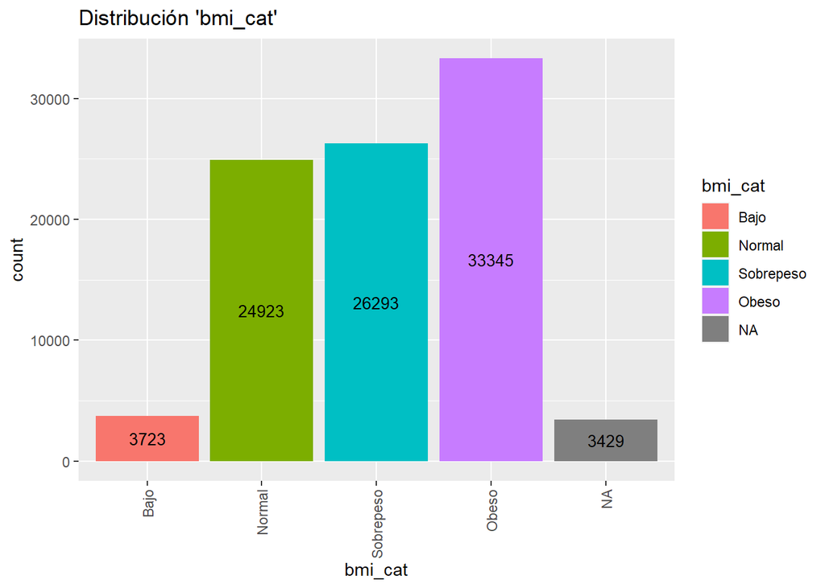

```r
ggplot(patientData, aes(x=bmi_cat, fill=bmi_cat)) + geom_bar() +
  theme(axis.text.x = element_text(angle = 90, vjust = 0.5, hjust=1)) +
  ggtitle("Distribución 'bmi_cat'") +
  stat_count(geom = "text", colour = "black", size = 3.5, aes(label = ..count..), position=position_stack(vjust=0.5))
```

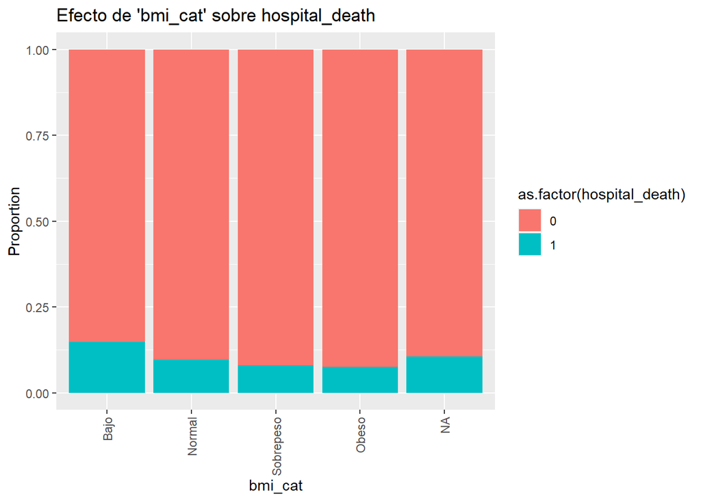

```r
ggplot(patientData,
       aes(x = bmi_cat,
           fill = as.factor(hospital_death))) +
  geom_bar(position = "fill") +
  labs(y = "Proportion") +
  theme(axis.text.x = element_text(angle = 90, vjust = 0.5, hjust=1)) +
  ggtitle("Efecto de 'bmi_cat' sobre hospital_death")
```

Tras discretizar la variable “bmi” vemos como algunas de las categorías, como el caso de un IMC bajo, está relacionada con la proporción de fallecidos. Por tanto, esta variable nos dará más información que las variables peso, altura o la propia variable “bmi”.

```r
patientData = patientData[, !(names(patientData) %in% c("height", "bmi"))]
```

Estudiemos las variables demográficas que nos quedan: ‘elective_surgery’ y ‘pre_icu_los_days’.

La variable ‘elective_surgery’ es una variable binaria que refleja si el paciente ha sido admitido por el hospital para una operación electiva, es decir, una operación no urgente.

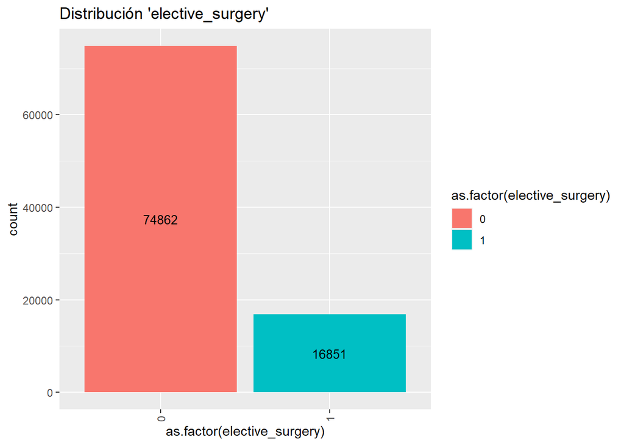

```r
ggplot(patientData, aes(x=as.factor(elective_surgery), fill=as.factor(elective_surgery))) + geom_bar() +
  theme(axis.text.x = element_text(angle = 90, vjust = 0.5, hjust=1)) +
  ggtitle("Distribución 'elective_surgery'") +
  stat_count(geom = "text", colour = "black", size = 3.5, aes(label = ..count..), position=position_stack(vjust=0.5))
```

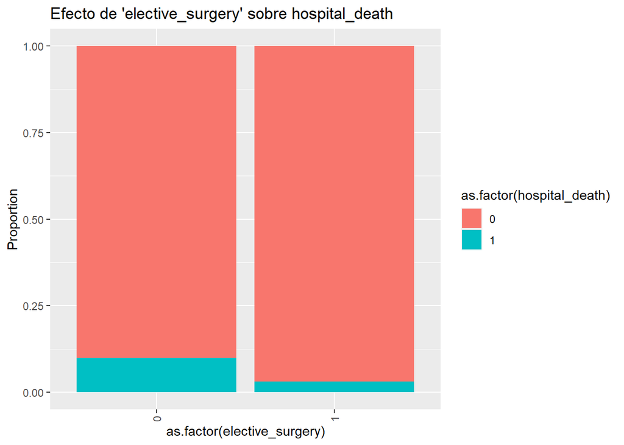

```r
ggplot(patientData,
       aes(x = as.factor(elective_surgery),
           fill = as.factor(hospital_death))) +
  geom_bar(position = "fill") +
  labs(y = "Proportion") +
  theme(axis.text.x = element_text(angle = 90, vjust = 0.5, hjust=1)) +
  ggtitle("Efecto de 'elective_surgery' sobre hospital_death")
```

Vemos una relación clara entre la variable ‘elective_surgery’ y la proporción de fallecidos. Cuando un paciente no es admitido para este tipo de operación, un 9% muere, mientras que para el caso contrario solo encontramos un 3%. Esto es lógico, pues aquellos pacientes admitidos para una operación electiva deben padecer enfermedades no demasiado urgentes.

Por último veremos la variable ‘pre_icu_los_days’, que nos informa acerca de los días que pasan entre la llegada del paciente la hospital y el ingreso en la UCI.

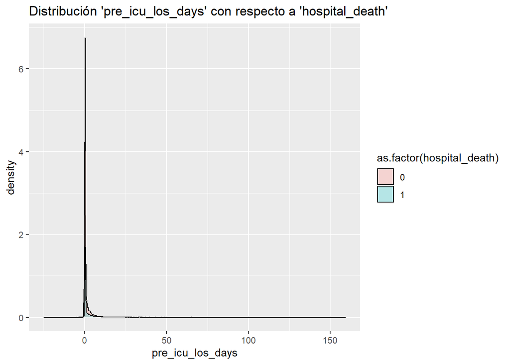

```r
ggplot(patientData,aes(x=pre_icu_los_days, fill=as.factor(hospital_death))) + geom_density(alpha=0.25) +
  ggtitle("Distribución 'pre_icu_los_days' con respecto a 'hospital_death'")
```

En el caso de esta variable parece que encontramos *outliers*, ya que tenemos valores negativos para una variable que representa días.

```r
# Numero de columnas con valores negativos de tiempo
nrow(patientData[patientData$pre_icu_los_days < 0, ])
```

```
## [1] 778
```

Descartaremos estos registros dado que no representan demasiados (778) sobre el total.

```r
patientData = patientData %>% filter(pre_icu_los_days > 0)
```

## 3.3 Imputación de valores nulos y generación de dataset final

Tras la exploración de los datos, acondicionaremos las variables seleccionadas para que generar un set de datos sin valores nulos. Primero imputaremos las variables numéricas. La función para guardar este dataset estará comentada para acelerar la ejecución del script.

```r
# Set de datos - valores nulos
# write.csv(patientData, "not_imputed_patientData2.csv", row.names = FALSE)
# Variables categóricas
cat_vars = c("hospital_id", "hospital_admit_source","icu_admit_source", "icu_id","icu_type", "apache_3j_bodysystem", "bmi_cat", "gender")
# Selección de variables numéricas
patientData_num = patientData[, !(names(patientData) %in% cat_vars)]
```

Usaremos la función mice(), de la librería con este mismo nombre, para imputar los valores de nuestras variables numéricas. La función está comentada ya que, debido al número de variables, tarda demasiado en ejecutarse. Por tanto, guardaremos posteriormente el set de datos de variables numéricas en un csv. Este será cargado para continuar la práctica.

```r
# Tarda bastante tiempo, por ello está comentado.
# imputed_Data = mice(patientData_num, m=1, maxit = 3, method = 'pmm', seed = 500)
# imputed_patientData_num = complete(imputed_Data,1)
# write.csv(imputed_patientData_num, "imputed_patientData_num_v2.csv", row.names = FALSE)

# Cargamos el fichero generado para seguir con el script.
imputed_patientData_num = read.csv("imputed_patientData_num_v2.csv", sep = ",")
imputed_patientData_num = imputed_patientData_num[, !(names(imputed_patientData_num) %in% "paco2_for_ph_apache")]
```

Una vez imputados las variables numéricas, pasamos a imputar los valores nulos en las variables categóricas. Para ello utilizaremos el valor más común en cada una de ellas.

```r
patientData_cat = patientData[, (names(patientData) %in% cat_vars)]
sort(colSums(is.na(patientData[, cat_vars])/length(patientData[, cat_vars]$hospital_id)*100), decreasing = TRUE)
```

```
## hospital_admit_source               bmi_cat  apache_3j_bodysystem
##           23.86269834            3.61024489            1.29895442
##      icu_admit_source                gender           hospital_id
##            0.12381913            0.02636889            0.00000000
##                icu_id              icu_type
##            0.00000000            0.00000000
```

```r
# hospital_admit_source
values_has = unique(patientData_cat$hospital_admit_source[!is.na(patientData_cat$hospital_admit_source)])
mode_has = values_has[which.max(tabulate(match(patientData_cat$hospital_admit_source, values_has)))]
patientData_cat$hospital_admit_source[is.na(patientData_cat$hospital_admit_source)] = mode_has
# bmi_cat
values_bmi = unique(patientData_cat$bmi_cat[!is.na(patientData_cat$bmi_cat)])
mode_bmi = values_bmi[which.max(tabulate(match(patientData_cat$bmi_cat, values_bmi)))]
patientData_cat$bmi_cat[is.na(patientData_cat$bmi_cat)] = mode_bmi
# apache_3j_bodysystem
values_apache = unique(patientData_cat$apache_3j_bodysystem[!is.na(patientData_cat$apache_3j_bodysystem)])
mode_apache = values_apache[which.max(tabulate(match(patientData_cat$apache_3j_bodysystem, values_apache)))]
patientData_cat$apache_3j_bodysystem[is.na(patientData_cat$apache_3j_bodysystem)] = mode_apache
# icu_admit_source
values_icu = unique(patientData_cat$icu_admit_source[!is.na(patientData_cat$icu_admit_source)])
mode_icu = values_icu[which.max(tabulate(match(patientData_cat$icu_admit_source, values_icu)))]
patientData_cat$icu_admit_source[is.na(patientData_cat$icu_admit_source)] = mode_icu
sort(colSums(is.na(patientData_cat)/length(patientData_cat$bmi_cat)*100), decreasing = TRUE)
```

```
##                gender           hospital_id hospital_admit_source
##            0.02636889            0.00000000            0.00000000
##      icu_admit_source                icu_id              icu_type
##            0.00000000            0.00000000            0.00000000
##  apache_3j_bodysystem               bmi_cat
##            0.00000000            0.00000000
```

```r
# gender
values_gender = unique(patientData_cat$gender[!is.na(patientData_cat$gender)])
mode_gender = values_gender[which.max(tabulate(match(patientData_cat$gender, values_gender)))]
patientData_cat$gender[is.na(patientData_cat$gender)] = mode_gender
```

Imputados ambos tipos de variables, podemos guardar el set de datos final en un fichero llamado “imputed_patientData.csv”.

```r
imputed_patientData = cbind(imputed_patientData_num, patientData_cat)
# Comentado para acelerar ejecución
# write.csv(imputed_patientData, "imputed_patientData_v3.csv", row.names = FALSE)
```